# UPRAK MPDW

```r
model5.ma2=Arima(data.ts, order=c(1,0,5),method="ML")
summary(model5.ma2) #AIC=1399.61
```

```
## Series: data.ts
## ARIMA(1,0,5) with non-zero mean
##
## Coefficients:
##          ar1      ma1      ma2      ma3      ma4      ma5      mean
##       0.9968  -0.1373  -0.2591  -0.1698  -0.1203  -0.0462  268.5295
## s.e.  0.0032   0.0470   0.0473   0.0441   0.0466   0.0461    2.4289
##
## sigma^2 = 0.9392:  log likelihood = -691.81
## AIC=1399.61   AICc=1399.91   BIC=1433.33
##
## Training set error measures:
##                      ME      RMSE       MAE        MPE      MAPE      MASE
## Training set 0.04131991 0.9623154 0.7387694 0.01411977 0.2748483 0.9421297
##                     ACF1
## Training set -0.01150194
```

```r
lmtest::coeftest(model5.ma2) #ma5 tidak signifikan
```

```
##
## z test of coefficients:
##
##              Estimate  Std. Error  z value  Pr(>|z|)
## ar1         0.9968213   0.0032189 309.6732 < 2.2e-16 ***
## ma1        -0.1372526   0.0469844  -2.9212 0.0034864 **
## ma2        -0.2591104   0.0473483  -5.4724 4.439e-08 ***
## ma3        -0.1698401   0.0441017  -3.8511 0.0001176 ***
## ma4        -0.1203242   0.0465828  -2.5830 0.0097941 **
## ma5        -0.0462037   0.0460683  -1.0029 0.3158893
## intercept 268.5295236   2.4288534 110.5581 < 2.2e-16 ***
## ---
## Signif. codes:  0 '***' 0.001 '**' 0.01 '*' 0.05 '.' 0.1 ' ' 1
```

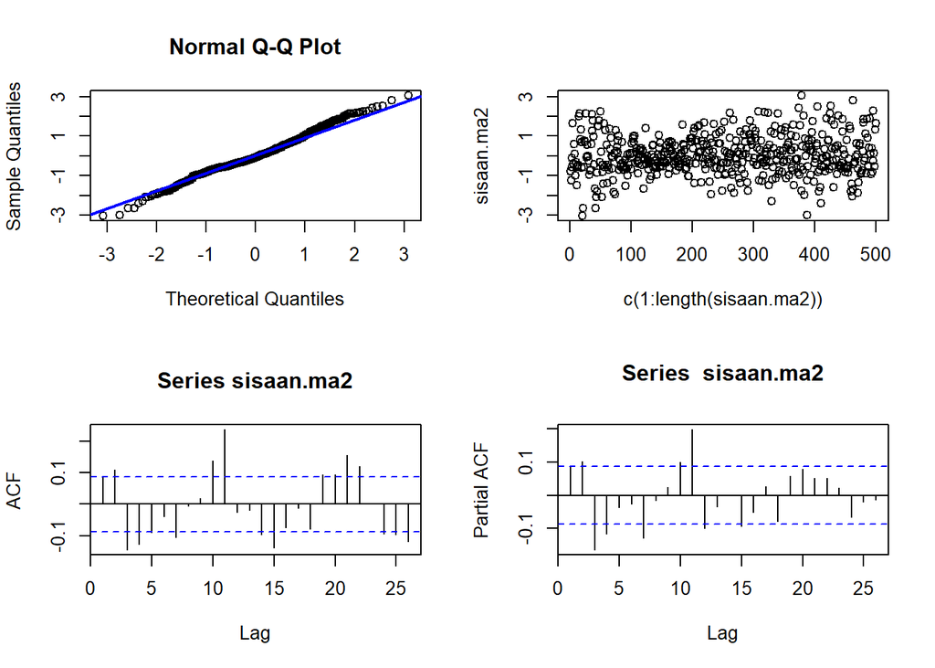

```r
sisaan.ma2 <- model1.ma2$residuals
par(mfrow=c(2,2))
qqnorm(sisaan.ma2)
qqline(sisaan.ma2, col = "blue", lwd = 2)
plot(c(1:length(sisaan.ma2)),sisaan.ma2)
acf(sisaan.ma2)
pacf(sisaan.ma2)
```

```r
par(mfrow = c(1,1))
```

```r
ks.test(sisaan.ma2,"pnorm")
```

```
##
##  Asymptotic one-sample Kolmogorov-Smirnov test
##
## data:  sisaan.ma2
## D = 0.056374, p-value = 0.08333
## alternative hypothesis: two-sided
```

Selain dengan eksplorasi, asumsi tersebut dapat diuji menggunakan uji formal. Pada tahapan ini uji formal yang digunakan untuk normalitas adalah uji Kolmogorov-Smirnov (KS). Hipotesis pada uji KS adalah sebagai berikut.

$H_0$ : Sisaan menyebar normal

$H_1$ : Sisaan tidak menyebar normal

Berdasarkan uji KS tersebut, didapat *p-value* sebesar 0.08333 yang lebih besar dari taraf nyata 5% sehingga tak tolak $H_0$ dan menandakan bahwa sisaan menyebar normal. Hal ini sesuai dengan hasil eksplorasi menggunakan plot kuantil-kuantil normal.

```r
Box.test(sisaan.ma2, type = "Ljung")
```

```
##
##  Box-Ljung test
##
## data:  sisaan.ma2
## X-squared = 3.7968, df = 1, p-value = 0.05135
```

Selanjutnya akan dilakukan uji formal untuk kebebasan sisaan menggunakan uji Ljung-Box. Hipotesis yang digunakan adalah sebagai berikut.

$H_0$ : Sisaan saling bebas

$H_1$ : Sisaan tidak tidak saling bebas

Berdasarkan uji Ljung-Box tersebut, didapat *p-value* sebesar 0.05135 yang lebih besar dari taraf nyata 5% sehingga tak tolak $H_0$ dan menandakan bahwa sisaan saling bebas. Hal ini berbeda dengan eksplorasi.

```r
Box.test((sisaan.ma2)^2, type = "Ljung")
```

```
##
##  Box-Ljung test
##
## data:  (sisaan.ma2)^2
## X-squared = 12.123, df = 1, p-value = 0.0004979
```

Hipotesis yang digunakan untuk uji kehomogenan ragam adalah sebagai berikut.

$H_0$ : Ragam sisaan homogen

$H_1$ : Ragam sisaan tidak homogen

Berdasarkan uji Ljung-Box terhadap sisaan kuadrat tersebut, didapat *p-value* sebesar 0.0004979 yang lebih kecil dari taraf nyata 5% sehingga tolak $H_0$ dan menandakan bahwa ragam sisaan tidak homogen.

```r
t.test(sisaan.ma2, mu = 0, conf.level = 0.95)
```

```
##
##  One Sample t-test
##
## data:  sisaan.ma2
## t = 0.63042, df = 499, p-value = 0.5287
## alternative hypothesis: true mean is not equal to 0
## 95 percent confidence interval:
##  -0.05905195  0.11485249
## sample estimates:
##  mean of x
## 0.02790027
```

Terakhir, dengan uji-t, akan dicek apakah nilai tengah sisaan sama dengan nol. Hipotesis yang diujikan sebagai berikut.

$H_0$ : nilai tengah sisaan sama dengan 0

$H_1$ : nilai tengah sisaan tidak sama dengan 0

Berdasarkan uji-ttersebut, didapat *p-value* sebesar 0.5287 yang lebih besar dari taraf nyata 5% sehingga tak tolak $H_0$ dan menandakan bahwa nilai tengah sisaan sama dengan nol.

```r
model1a.ma2=Arima(data.ts, order=c(1,0,1),method="ML")
summary(model1a.ma2) #1452.71
```

```
## Series: data.ts
## ARIMA(1,0,1) with non-zero mean
##
## Coefficients:
##          ar1     ma1      mean
##       0.9496  0.0057  268.2745
## s.e.  0.0152  0.0582    0.8813
##
## sigma^2 = 1.054:  log likelihood = -722.36
## AIC=1452.71   AICc=1452.79   BIC=1469.57
##
## Training set error measures:
##                       ME     RMSE       MAE         MPE      MAPE      MASE
## Training set 0.007937784 1.023718 0.7786888 0.001492382 0.2896551 0.9930376
##                     ACF1
## Training set 0.001265083
```

```r
lmtest::coeftest(model1a.ma2) #ma1 tidak signifkan
```

```
##
## z test of coefficients:
##
##             Estimate Std. Error z value Pr(>|z|)
## ar1       9.4957e-01 1.5225e-02  62.370   <2e-16 ***
## ma1       5.7056e-03 5.8197e-02   0.098   0.9219
## intercept 2.6827e+02 8.8128e-01 304.414   <2e-16 ***
## ---
## Signif. codes:  0 '***' 0.001 '**' 0.01 '*' 0.05 '.' 0.1 ' ' 1
```

```r
model1b.ma2=Arima(data.ts, order=c(2,0,1),method="ML")
summary(model1b.ma2) #1452.87
```

```
## Series: data.ts
## ARIMA(2,0,1) with non-zero mean
##
## Coefficients:
##          ar1     ar2     ma1      mean
##       0.3225  0.5918  0.6728  268.2689
## s.e.  0.3396  0.3246  0.3222    0.8620
##
## sigma^2 = 1.053:  log likelihood = -721.44
## AIC=1452.87   AICc=1452.99   BIC=1473.95
##
## Training set error measures:
##                       ME    RMSE       MAE         MPE      MAPE      MASE
## Training set 0.007701174 1.02183 0.7776996 0.001409464 0.2892821 0.9917761
##                     ACF1
## Training set -0.03429028
```

```r
lmtest::coeftest(model1b.ma2) #ar1 tidak signifikan
```

```
##
## z test of coefficients:
##
##            Estimate Std. Error  z value Pr(>|z|)
## ar1         0.32252    0.33957   0.9498  0.34222
## ar2         0.59175    0.32464   1.8228  0.06834 .
## ma1         0.67282    0.32219   2.0883  0.03677 *
## intercept 268.26891    0.86198 311.2234  < 2e-16 ***
## ---
## Signif. codes:  0 '***' 0.001 '**' 0.01 '*' 0.05 '.' 0.1 ' ' 1
```

Berdasarkan kedua model hasil *overfitting* di atas, model ARIMA(1,0,1) dan ARIMA(2,0,1) memiliki AIC yang lebih besar dibandingkan dengan model ARIMA(1,0,2) tidak seluruhnya signifikan.